# Homework: Map of Cats on the Move!

Marisa

2023-03-09

### Introduction

This is my homework assignment for week 7. I will be creating a map using the *Cats on the Move!* dataset.

### Libraries

We will need to load the following libraries:

```r
library(tidyverse)
library(here)
library(maps)
library(mapdata)
library(mapproj)
library(ggmap)
library(ggsn)
```

### Data

We first need to load in our Cat data

```r
# loads our cat data
cats <- read_csv('https://raw.githubusercontent.com/rfordatascience/tidytuesday/master/data/2023/2023-01-31/cats_uk.csv')

# lets us look at our cats data
view(cats)
```

Since this cat data was taken from the United Kingdom (UK), let’s select map data for just the UK. Specifically, our cat data is mostly in the counties of Cornwall & Devon.

```r
# gets longitude & latitude data from the UK, specifically Cornwall county
geocode("Cornwall")
```

```
## # A tibble: 1 × 2
##     lon   lat
##   <dbl> <dbl>
## 1 -5.05  50.3
```

```r
# Creates dataframe with the lon & lat found previously
Cornwall <- data.frame(lon = -5.052713, lat = 50.26605)
```

### Analysis

Next, let’s just select for the relevant cat data:

1. tag ID (identifier for cat)
2. event ID
3. location (longitude)
4. location (latitude)

```r
# Selects for the following columns in our cats data
cats <- cats %>%
  select(tag_id, event_id, location_long, location_lat)

view(cats)
```

I want to plot 10 random cats. To do this, I will randomly generate 10 numbers and select from the list of cat IDs. Then I will use the associated longitude & latitude data.

```r
# Arranges cat tag IDs alphabetically and lists distinct cat IDs
  cats_unique <- cats %>%
  distinct(tag_id, .keep_all = FALSE) %>%
  arrange(tag_id)

# Selects 10 random cat IDs from the alphabetized cat ID list, without repeats
  cats_random <- cats_unique[sample(1:101, 10, replace = FALSE),1]

view(cats_random)

# Joins randomly selected cat ID list with associated longitude & latitude data values into new dataset
ten_cats <- left_join(cats_random, cats) %>%
  group_by (tag_id, event_id)

view(ten_cats)
```

### Plot

Now, let’s plot our points on our map!

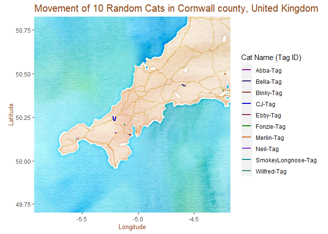

This map shows movement of 10 randomly selected cats in the United Kingdom, specifically near Cornwall county

```r
# Gets map of Cornwall county, zoomed out to see neighboring counties
Cornwall_map <- get_map(Cornwall, zoom = 9, maptype = "watercolor")

CatMap <- ggmap(Cornwall_map)+

  # Plots cat data as a scatterplot
  geom_line(data = ten_cats,
             # x & y are coordinates of cat location
             aes(x = location_long,
                 y = location_lat,
                 # color = tag id for each cat
                 color = tag_id),
             size = 0.8)+

  # sets colors for points manually
  scale_color_manual(values = c("darkmagenta","midnightblue","tomato4","mediumblue","violetred4","green4","chocolate3","purple3","turquoise4","seagreen4"))+

  # sets labels for plot, axes, etc.
  labs(x = "Longitude",
       y = "Latitude",
       color = "Cat Name (Tag ID)",
       title = "Movement of 10 Random Cats in Cornwall county, United Kingdom")+

  # sets size and color for plot elements
  theme(axis.title = element_text(size = 10, color = "saddlebrown"),
        plot.title = element_text(size = 15, color = "saddlebrown"))

CatMap
```

###### Data Source:

Kays R, Dunn RR, Parsons AW, Mcdonald B, Perkins T, Powers S, Shell L, McDonald JL, Cole H, Kikillus H, Woods L, Tindle H, Roetman P (2020) The small home ranges and large local ecological impacts of pet cats. Animal Conservation. doi:10.1111/acv.12563

McDonald JL, Cole H (2020) Data from: The small home ranges and large local ecological impacts of pet cats [United Kingdom]. Movebank Data Repository. doi:10.5441/001/1.pf315732

###### Map Source: ggmap

D. Kahle and H. Wickham. ggmap: Spatial Visualization with ggplot2. The R Journal, 5(1), 144-161. URL http://journal.r-project.org/archive/2013-1/kahle-wickham.pdf